# Exploratory Report of Juvenile Snowshoe Hares in Bonanza Experimental Forest

Joe Walderman

11/14/2020

### Introduction

The northern boreal forests are the habitat of the snowshow hare, a keystone species. This report utilizes a study on populations of the species in Bonanza Experimental Forest conducted by University of Alaska - Fairbanks from 1999 - 2012. This study utilized capture-recapture methods to develop an understanding of the population as a whole. Throughout the report, weight is compared based on sex of the snowshoe hairs. Further on, the relationship between weight and hind foot length is explored.

### Data and Analysis

These relationships and comparisons are performed using summary statistics, data visualization, central tendency comparison, and linear regression modeling. This report utilized data collected from 1999-2012 of showshoe hare trappings in Bonanza Experimental Forest.

### Exploratory Findings

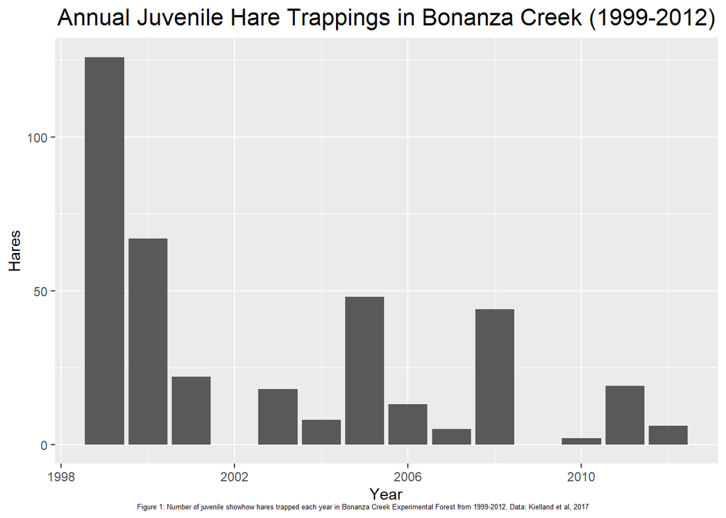

**Figure 1.**: Number of juvenile showhow hares trapped each year in Bonanza Creek Experimental Forest from 1999-2012. Data: Kielland et al, 2017"

The largest number of trappings (126) occurred in the first year of this study in 1999, and declined in subsequent years, though there are staggered upticks after a certain low amount is reached. Each rebound, though, is smaller every time it occurs. The lowest trapping count for a year in this study was 2. It seems that there has been an overall decline in the hare population in these areas based on these samples, with intermittent periods of recovery followed by decline. Another point of interest in the notable difference between the mean 31.5 and median 18 yearly hare trappings, with the median tending much lower. Important to note in this data is that while there were hares trappings recorded in 2002 and 2009, none of these observations had a categorization for age, and thus are not included in this analysis. Further, to standardize this data accross years it is suggested that the same amount of days and traps be utilized for each year of collection.

### Comparing weights of male vs female juvenile hares at different capture sites

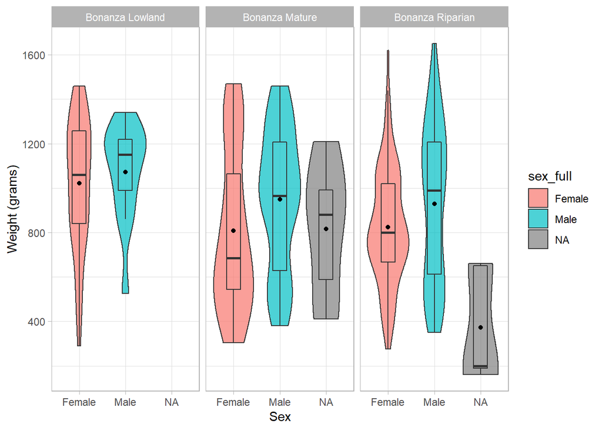

Males generally have a higher density of observations in higher weight recordings than females. The width of the plot represents the density of observations at that weight level. The boxplots indicate the sample sizes which can contribute to the variance and the mean which can more easily illustrate the differences between the two.

**Table 1.** Descriptive statistics (mean, standard deviation, and sample size) for male and female juvenile hares. Data: Kielland et al. 2017.

| Sex | Mean Weight (g) | Standard Deviation (g) | Sample Size |
| --- | --- | --- | --- |
| Female | 855.39 | 292.25 | 197 |
| Male | 945.86 | 333.22 | 163 |

#### Relationships between juvenle weight and hind foot length

##### Linear Regression Model

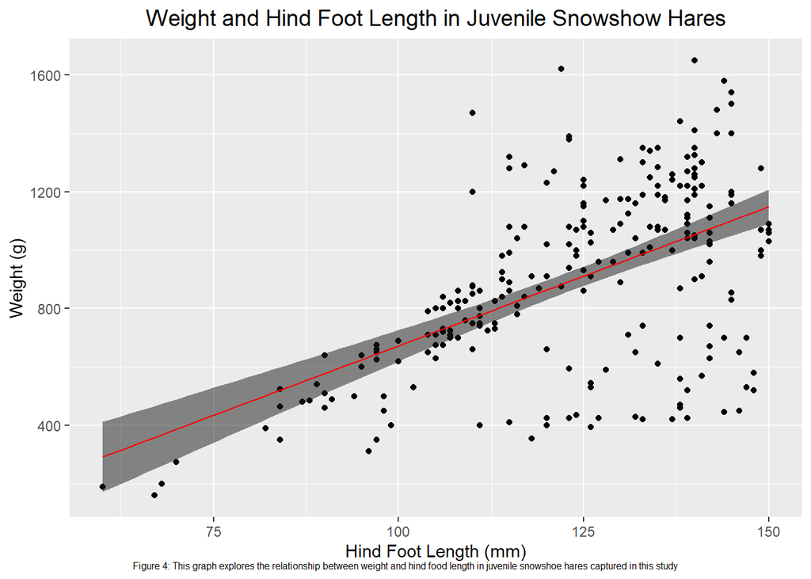

I have some concerns here about the homoscedacisity of the relationship. It seems that the residuals are even up to about the 100mm hind foot length but beyond that the model seems to be heteroscedastic, as the distance of the residuals from the regression line increases.

- The hindfoot coefficient indicates we should expect hare weight (g) to increase by 9.5234 grams for every 1 mm increase in hind foot length
- The Multiple R<sup>2</sup> value is 0.2988 - meaning that 29.9% of variance in weight is explained by hind foot length

Here, we see that there is a moderate positive correlation between snowshoe hare hindfoot length and weight(*r* = 0.55, t(247) = 10.26, p < 0.001).

I have some concerns here about the homoscedacisity of the relationship. It seems that the residuals are even up to about the 100mm hind foot length but beyond that the model seems to be heteroscedastic, as the distance of the residuals from the regression line increases.

### Summary

The following were suggested from the exploratory data analysis:

-Juvenile showshoe hares have fluctuated in population but overall declined from 1999 - 2012.

-Juvenile male snowshoe hares tend to weigh more than juvenile female snowshoe hares.

-There is a positive correlation between weight and hindd foot length with a moderate linear relationship.

### Citation

Kielland, K., F.S. Chapin, R.W. Ruess, and Bonanza Creek LTER. 2017. Snowshoe hare physical data in Bonanza Creek Experimental Forest: 1999-Present ver 22. Environmental Data Initiative. https://doi.org/10.6073/pasta/03dce4856d79b91557d8e6ce2cbcdc14 (Accessed 2020-11-21).